# Lecture Lab 2

Leon Eyrich Jessen

2026

# Data Visualisation I

## First: Make sure you’re on track!

### Lab I Learning Objectives

- Navigate the RStudio IDE and master the very basics of R
- Create, edit and run a basic Quarto document
- Explain why reproducible data analysis is important
- Describe the components of a reproducible data analysis

### Where should you be by now?

- In a group
- On Slack
- On the RStudio Cloud Server
- On GitHub

*If any of this is not the case, see the `Getting Started` section on the course site*

## What is Data Visualisation?

- Think about Hadley’s and Hans’ lectures, the book chapter and paper you read for today
- Use the next 5 minutes to think and talk to the person next to you
- Then, write your thoughts on Slack in the channel for Teaching lab 2

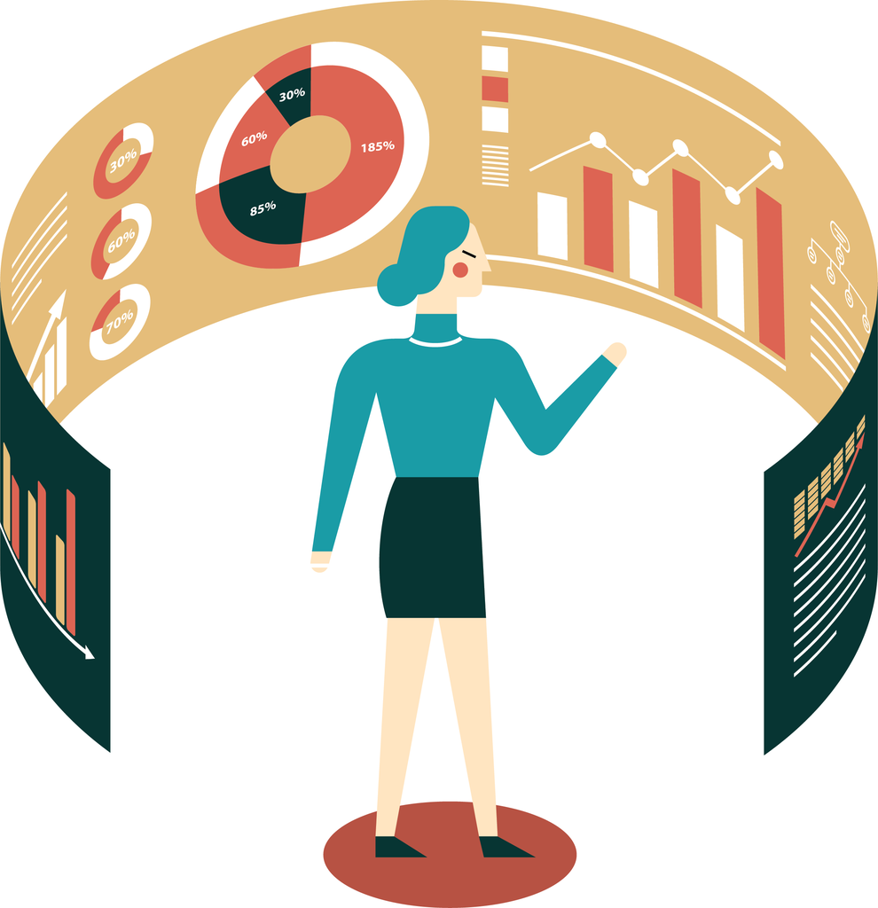

## On Data Visualisation

- Depending on where your read, something along the lines of:
  - *The graphical representation of information and data*
  - *Uses visual elements like charts, graphs and maps*
  - *Provide an accessible way to see and understand trends, outliers and patterns*
- Data visualisation is your means to summarise and communicate key messages
  - Within research
  - Within industry
- It is not easy!
  - Anyone can make a plot, but an impactful data visualisation requires true skills

## What is wrong here?

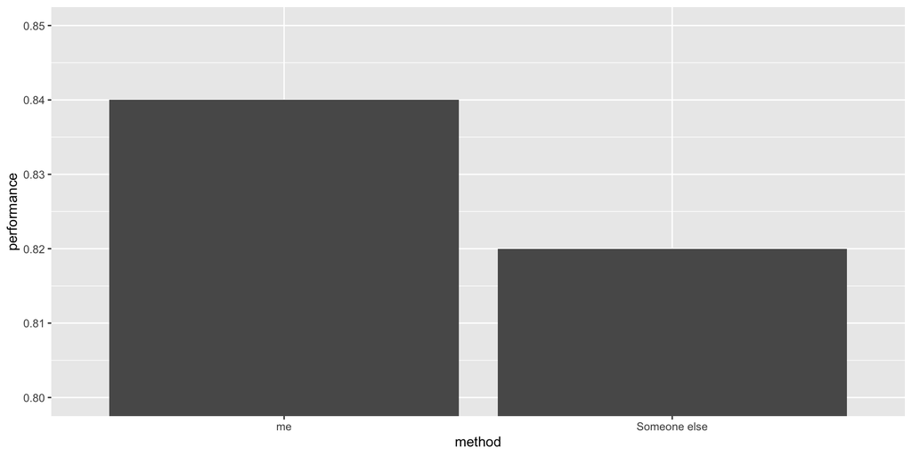

## Should have been

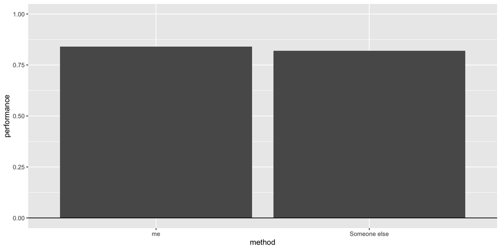

## What’s wrong here?

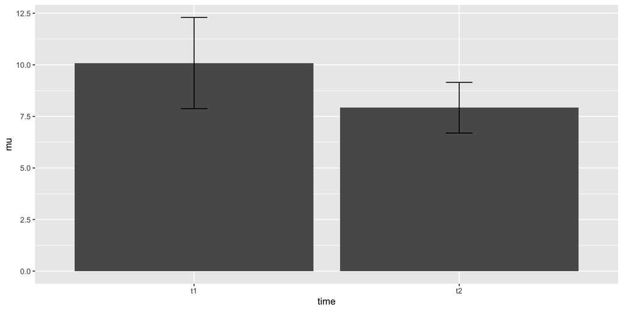

## Should have been

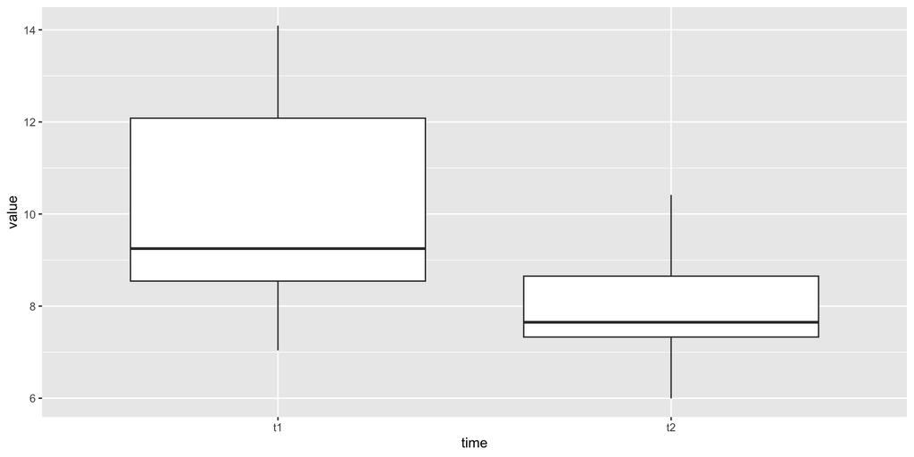

## Or maybe even

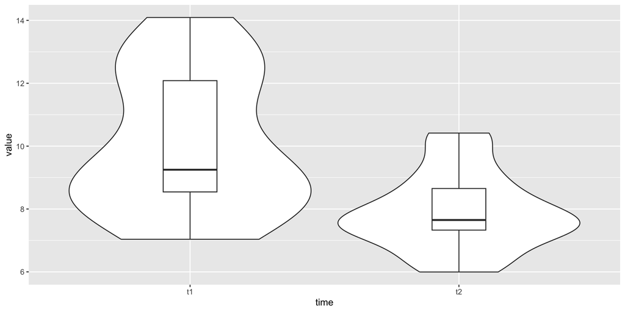

## What is this?

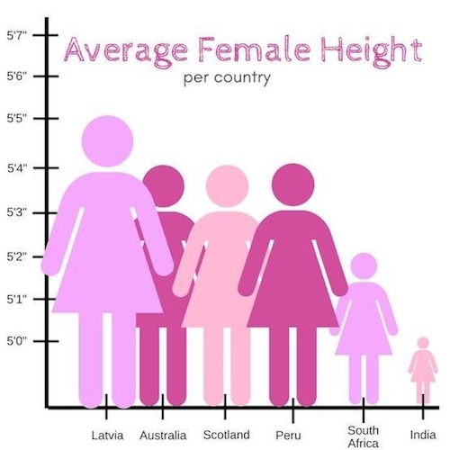

## Or this?

[figure not shown]

## Or this?

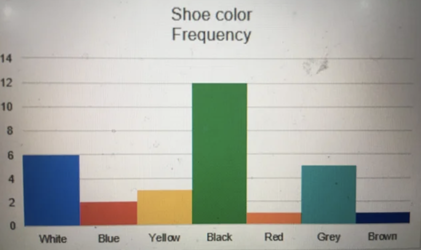

## Or this?

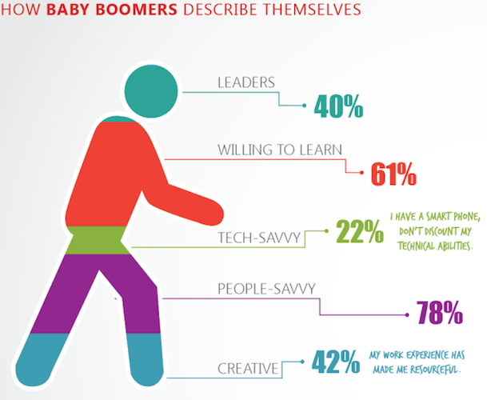

## Or this?

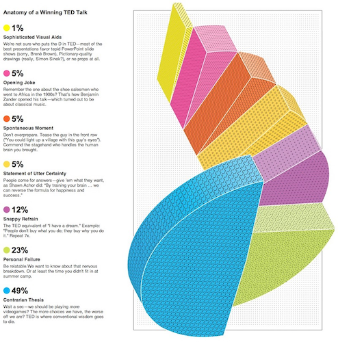

## Or this?

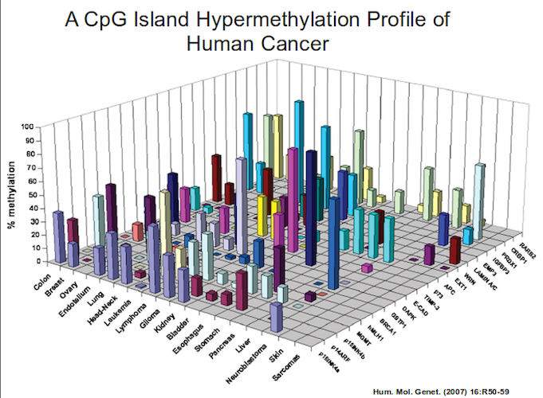

## Or this?

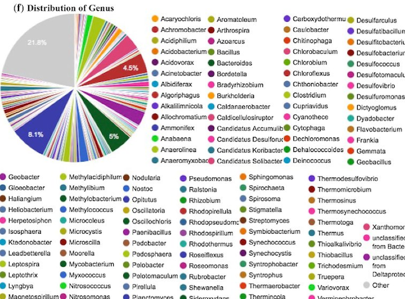

## …and then there is this one?!?

[figure not shown]

## …and then there is this one?!?

[figure not shown]

## Or this?

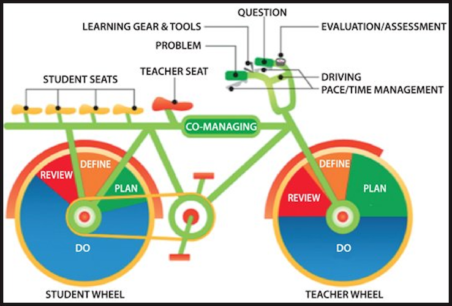

- Don’t even know where to begin with this one…

## In Summary on Data Visualisation

- Think carefully about *exactly* what it is, you want to communicate with your visualisation
- Remove redundant information
- Be honest and show your data
- Less is more, do not cram 3 plots into 1
- Do not make a fancy, but information deprived plot
- Think about colour choice - Separation, but also quite a few people are colour blind
- Today is meant as in intro, data visualisation will be an integrated part of the rest of the course

## ggplot, the Grammar of Graphics

### The basic syntax of ggplot

- In a new code chunk in your Quarto document, input and run:

````markdown
```{r}
ggplot(data = my_data,
       mapping = aes(x = v1, y = v2)) +
  geom_point()
```
````

- Define your data
- Map variables in your plot to your visualisation
- Choose a graphical representation
- Let us look at that in another way

## ggplot, the Grammar of Graphics

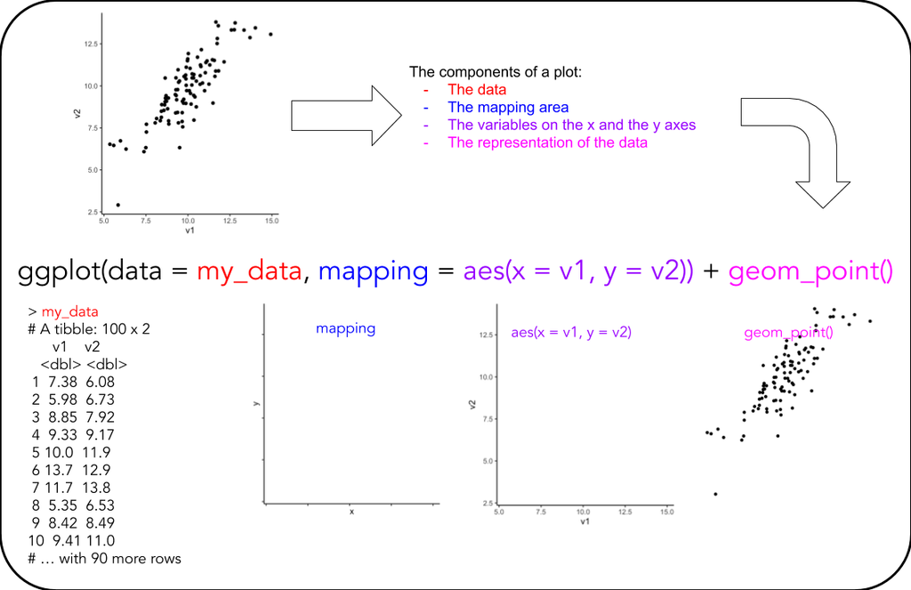

## Example - Scatter plot

```r
library("tidyverse")
ggplot(data = datasets::Puromycin,
       mapping = aes(x = conc,
                     y = rate)) +
  geom_point()
```

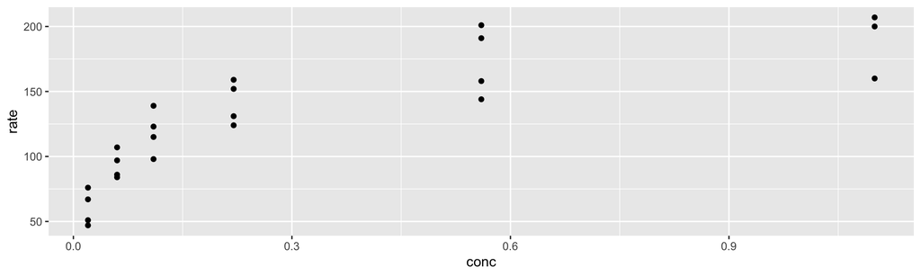

# Break and the it is time for exercises…